# Module 20

#### Hemi-module gene counts:

206 probesets in hemi-module A.  
79 probesets in hemi-module B.  
Note: While the mapping of probesets to genes is usually one-to-one, some genes are targeted by multiple probesets, some probesets target multiple genes, and some probesets do not target any genes (i.e., the region of the genome they match is no longer considered genic).

#### Contrast SVE:

Signed variance explained (SVE) provides an indication of how similar a set of fold changes are to a gene module’s weight vector. An SVE value of 0.3, for example, indicates that 30% of the variance explained by the entire module set is accounted for by the module in question. Shown here are the SVE values for this module across a compendium of fold changes (contrasts). Extreme SVE values (e.g., > 0.05) indicate that those contrasts specifically induce (orange dots) or specifically repress (blue dots) this module. Examining the experimental conditions being compared in such contrasts (see tables below the figure) may provide insight into the gene module’s function.

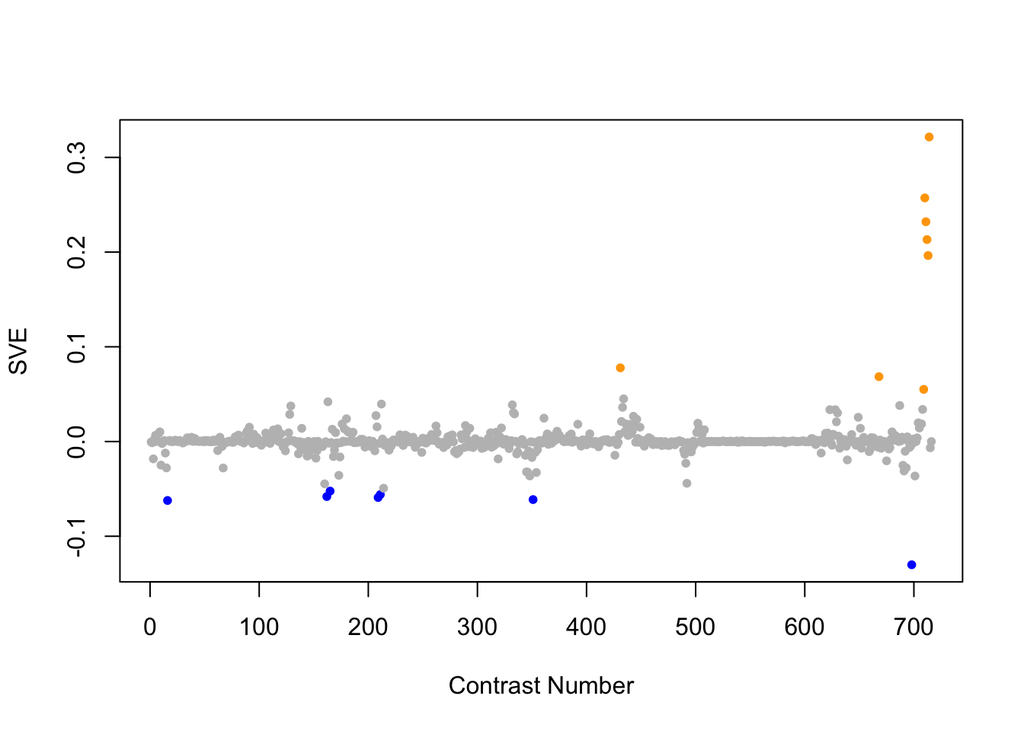

Positive SVE Contrasts:

|  | Contrast.Num | SVE | GEO.GSE | Cond.1 | Cond.2 | Mutation |
| --- | --- | --- | --- | --- | --- | --- |
| GSE11055.s2t5.vs.s2t2 | 714 | 0.32 | GSE11055 | L1 larvae 6 hr after hatching in the absence of food | L1 larvae 0 hr after hatching in the absence of food |  |
| GSE11055.s2t6.vs.s2t2 | 710 | 0.26 | GSE11055 | L1 larvae 12 hr after hatching in the absence of food | L1 larvae 0 hr after hatching in the absence of food |  |
| GSE11055.s2t7.vs.s2t2 | 711 | 0.23 | GSE11055 | L1 larvae 15 hr after hatching in the absence of food | L1 larvae 0 hr after hatching in the absence of food |  |
| GSE11055.s2t8.vs.s2t2 | 712 | 0.21 | GSE11055 | L1 larvae 24 hr after hatching in the absence of food | L1 larvae 0 hr after hatching in the absence of food |  |
| GSE11055.s2t4.vs.s2t2 | 713 | 0.20 | GSE11055 | L1 larvae 3 hr after hatching in the absence of food | L1 larvae 0 hr after hatching in the absence of food |  |
| GSE27677A.s3t2.vs.s3t1 | 431 | 0.08 | GSE27677 | daf-16, Fast , rep 1 | daf-16, Fed , rep 1 |  |
| GSE15016.s4t1.vs.s0t1 | 668 | 0.07 | GSE15016 | young adult_24hr BPA exposure_rep1 | young adult_not exposured_rep1 |  |
| GSE11055.s2t3.vs.s2t2 | 709 | 0.06 | GSE11055 | L1 larvae 1 hr after hatching in the absence of food | L1 larvae 0 hr after hatching in the absence of food |  |

Negative SVE Contrasts:

|  | Contrast.Num | SVE | GEO.GSE | Cond.1 | Cond.2 | Mutation |
| --- | --- | --- | --- | --- | --- | --- |
| GSE11055.s3t4.vs.s2t4 | 698 | -0.13 | GSE11055 | L1 larvae 3 hr after hatching in the absence of food in the alternative starvation buffer M9 | L1 larvae 3 hr after hatching in the absence of food |  |
| GSE9682.s0t2.vs.s0t1 | 16 | -0.06 | GSE9682 | N2-controlRNAi-fed-biological rep1 | N2-controlRNAi-fasting-biological rep1 |  |
| GSE38997.s3t4.vs.s3t1 | 351 | -0.06 | GSE38997 | experiment 1 UVC- and EtBr-exposed samples at 51 h 1eu51 | experiment 4 UVC- and EtBr-exposed samples at 3 h 4eu3 |  |
| GSE42689.s2t1.vs.s1t1 | 209 | -0.06 | GSE42689 | mek-1 fed 1 | mek-1 fasted 1 |  |
| GSE47778.s1t2.vs.s3t2 | 162 | -0.06 | GSE47778 | N2; starvation; replicate 1 | daf-16; starvation; replicate 1 | daf-16 |
| GSE42689.s4t1.vs.s1t1 | 211 | -0.06 | GSE42689 | mlk-1 fed 1 | mek-1 fasted 1 |  |
| GSE47778.s1t2.vs.s4t2 | 165 | -0.05 | GSE47778 | N2; starvation; replicate 1 | daf-2;daf-16; starvation; replicate 1 | daf-2;daf-16 |

$~$

#### Contrast SVE, Up-Regulated Genes Only:

Calculating SVE for up-regulated and down-regulated genes separately may be more informative in many cases than projecting the up- and down- gene sets together. This is due to the fact that the weight distribution of many modules is highly skewed, indicating that only one of the hemi-modules may be biologically meaningful (i.e., a set of genes are strongly correlated by only a few genes (or none) are strongly anti-correlated to that set.)

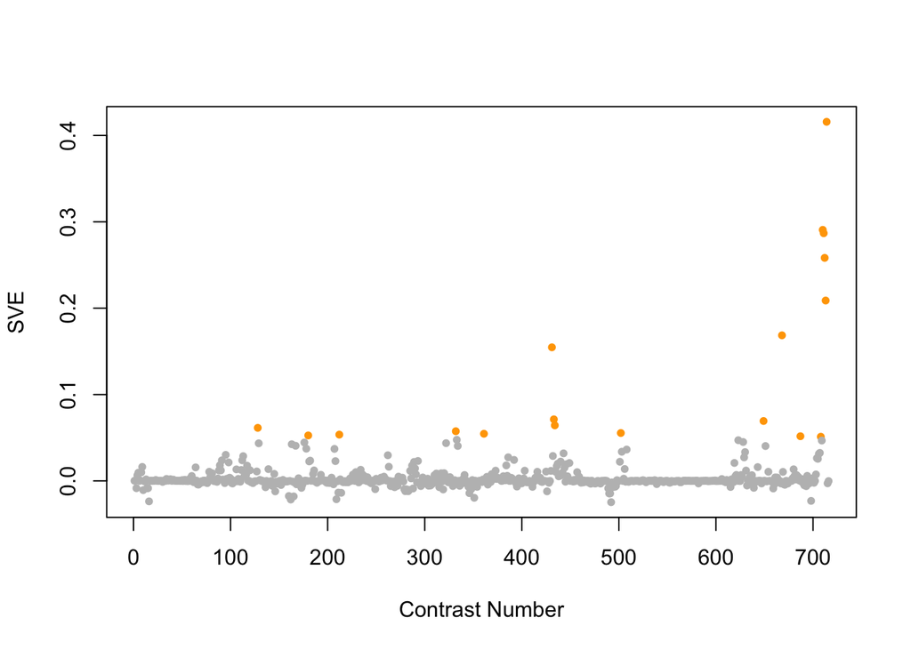

Positive SVE Contrasts:

|  | Contrast.Num | SVE | GEO.GSE | Cond.1 | Cond.2 | Mutation |
| --- | --- | --- | --- | --- | --- | --- |
| GSE11055.s2t5.vs.s2t2 | 714 | 0.42 | GSE11055 | L1 larvae 6 hr after hatching in the absence of food | L1 larvae 0 hr after hatching in the absence of food |  |
| GSE11055.s2t6.vs.s2t2 | 710 | 0.29 | GSE11055 | L1 larvae 12 hr after hatching in the absence of food | L1 larvae 0 hr after hatching in the absence of food |  |
| GSE11055.s2t7.vs.s2t2 | 711 | 0.29 | GSE11055 | L1 larvae 15 hr after hatching in the absence of food | L1 larvae 0 hr after hatching in the absence of food |  |
| GSE11055.s2t8.vs.s2t2 | 712 | 0.26 | GSE11055 | L1 larvae 24 hr after hatching in the absence of food | L1 larvae 0 hr after hatching in the absence of food |  |
| GSE11055.s2t4.vs.s2t2 | 713 | 0.21 | GSE11055 | L1 larvae 3 hr after hatching in the absence of food | L1 larvae 0 hr after hatching in the absence of food |  |
| GSE15016.s4t1.vs.s0t1 | 668 | 0.17 | GSE15016 | young adult_24hr BPA exposure_rep1 | young adult_not exposured_rep1 |  |
| GSE27677A.s3t2.vs.s3t1 | 431 | 0.15 | GSE27677 | daf-16, Fast , rep 1 | daf-16, Fed , rep 1 |  |
| GSE27677A.s1t2.vs.s1t1 | 433 | 0.07 | GSE27677 | kgb-1, Fast , rep 1 | kgb-1, Fed , rep 1 |  |
| GSE16405.s2t1.vs.s1t1 | 649 | 0.07 | GSE16405 | nth-1_1 | N2_1 | nth-1 |
| GSE27677A.s0t2.vs.s0t1 | 434 | 0.06 | GSE27677 | N2, Fast , rep 1 | N2, Fed , rep 1 |  |
| GSE54011.s3t1.vs.s0t1 | 128 | 0.06 | GSE54011 | Ce 0.2 mM Se | Ce 0 mM Se |  |
| GSE38997.s2t2.vs.s1t2 | 332 | 0.06 | GSE38997 | experiment 4 EtBr-exposed samples at 24 h 4e24 | experiment 4 control samples at 24 h 4c24 |  |
| GSE22660.s1t1.vs.s0t1 | 502 | 0.06 | GSE22660 | 100ng/ml ivermectin exposure, biological rep 1 | 100ng/ml DMSO control, biological rep 1 |  |
| GSE37432.s2t1.vs.s0t1 | 361 | 0.05 | GSE37432 | piwi n4503 nDf57 rep1 | N2 rep1 | prg-1;prg-2 |
| GSE42689.s3t1.vs.s2t1 | 212 | 0.05 | GSE42689 | mlk-1 fasted 1 | mek-1 fed 1 |  |
| GSE47778.s4t2.vs.s4t1 | 180 | 0.05 | GSE47778 | daf-2;daf-16; starvation; replicate 1 | daf-2;daf-16; replicate 1 |  |
| GSE12298C.s2t1.vs.s0t1 | 687 | 0.05 | GSE12298 | mefloquine_mid_dose-rep1 | mefloquine_control-rep1 |  |
| GSE11055.s1t8.vs.s1t1 | 708 | 0.05 | GSE11055 | L2 larvae 24 hr after hatching in the presence of food | embryo 2 hr before hatching |  |

Negative SVE Contrasts:

|  | Contrast.Num | SVE | GEO.GSE | Cond.1 | Cond.2 | Mutation |
| --- | --- | --- | --- | --- | --- | --- |
| GSE23528B.s1t6.vs.s1t1 | 492 | -0.02 | GSE23528 | Adult at T46 in CC, time-series experiment 3 | Adult at T26 in CC, time-series experiment 3 |  |
| GSE9682.s0t2.vs.s0t1 | 16 | -0.02 | GSE9682 | N2-controlRNAi-fed-biological rep1 | N2-controlRNAi-fasting-biological rep1 |  |
| GSE11055.s3t4.vs.s2t4 | 698 | -0.02 | GSE11055 | L1 larvae 3 hr after hatching in the absence of food in the alternative starvation buffer M9 | L1 larvae 3 hr after hatching in the absence of food |  |
| GSE47778.s1t2.vs.s3t2 | 162 | -0.02 | GSE47778 | N2; starvation; replicate 1 | daf-16; starvation; replicate 1 | daf-16 |
| GSE42689.s2t1.vs.s1t1 | 209 | -0.02 | GSE42689 | mek-1 fed 1 | mek-1 fasted 1 |  |

$~$

#### Contrast SVE, Down-Regulated Genes Only:

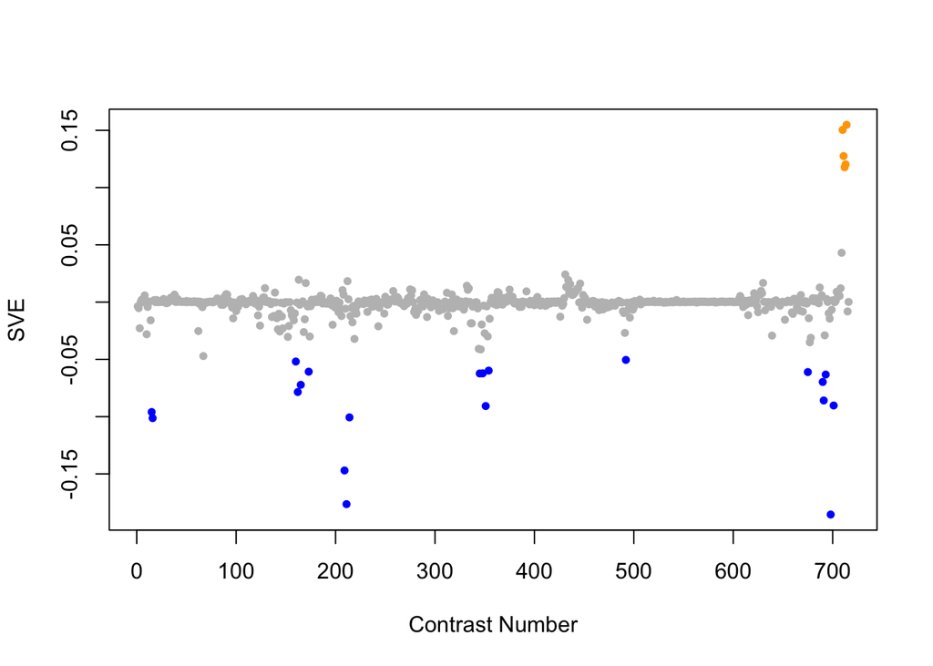

Positive SVE Contrasts:

|  | Contrast.Num | SVE | GEO.GSE | Cond.1 | Cond.2 | Mutation |
| --- | --- | --- | --- | --- | --- | --- |
| GSE11055.s2t5.vs.s2t2 | 714 | 0.15 | GSE11055 | L1 larvae 6 hr after hatching in the absence of food | L1 larvae 0 hr after hatching in the absence of food |  |
| GSE11055.s2t6.vs.s2t2 | 710 | 0.15 | GSE11055 | L1 larvae 12 hr after hatching in the absence of food | L1 larvae 0 hr after hatching in the absence of food |  |
| GSE11055.s2t7.vs.s2t2 | 711 | 0.13 | GSE11055 | L1 larvae 15 hr after hatching in the absence of food | L1 larvae 0 hr after hatching in the absence of food |  |
| GSE11055.s2t4.vs.s2t2 | 713 | 0.12 | GSE11055 | L1 larvae 3 hr after hatching in the absence of food | L1 larvae 0 hr after hatching in the absence of food |  |
| GSE11055.s2t8.vs.s2t2 | 712 | 0.12 | GSE11055 | L1 larvae 24 hr after hatching in the absence of food | L1 larvae 0 hr after hatching in the absence of food |  |

Negative SVE Contrasts:

|  | Contrast.Num | SVE | GEO.GSE | Cond.1 | Cond.2 | Mutation |
| --- | --- | --- | --- | --- | --- | --- |
| GSE11055.s3t4.vs.s2t4 | 698 | -0.19 | GSE11055 | L1 larvae 3 hr after hatching in the absence of food in the alternative starvation buffer M9 | L1 larvae 3 hr after hatching in the absence of food |  |
| GSE42689.s4t1.vs.s1t1 | 211 | -0.18 | GSE42689 | mlk-1 fed 1 | mek-1 fasted 1 |  |
| GSE42689.s2t1.vs.s1t1 | 209 | -0.15 | GSE42689 | mek-1 fed 1 | mek-1 fasted 1 |  |
| GSE9682.s0t2.vs.s0t1 | 16 | -0.10 | GSE9682 | N2-controlRNAi-fed-biological rep1 | N2-controlRNAi-fasting-biological rep1 |  |
| GSE42689.s4t1.vs.s3t1 | 214 | -0.10 | GSE42689 | mlk-1 fed 1 | mlk-1 fasted 1 |  |
| GSE9682.s2t2.vs.s2t1 | 15 | -0.10 | GSE9682 | N2-Cel-TORRNAi-fed-biological rep1 | N2-Cel-TORRNAi-fasting-biological rep1 |  |
| GSE38997.s3t4.vs.s3t1 | 351 | -0.09 | GSE38997 | experiment 1 UVC- and EtBr-exposed samples at 51 h 1eu51 | experiment 4 UVC- and EtBr-exposed samples at 3 h 4eu3 |  |
| GSE11055.s1t5.vs.s2t5 | 701 | -0.09 | GSE11055 | L1 larvae 6 hr after hatching in the presence of food | L1 larvae 6 hr after hatching in the absence of food |  |
| GSE11055.s4t7.vs.s2t7 | 691 | -0.09 | GSE11055 | L1 larvae fed for 12 hr after hatching and then starved for 3 hr | L1 larvae 15 hr after hatching in the absence of food |  |
| GSE47778.s1t2.vs.s3t2 | 162 | -0.08 | GSE47778 | N2; starvation; replicate 1 | daf-16; starvation; replicate 1 | daf-16 |
| GSE47778.s1t2.vs.s4t2 | 165 | -0.07 | GSE47778 | N2; starvation; replicate 1 | daf-2;daf-16; starvation; replicate 1 | daf-2;daf-16 |
| GSE11055.s1t6.vs.s2t6 | 690 | -0.07 | GSE11055 | L1 larvae 12 hr after hatching in the presence of food | L1 larvae 12 hr after hatching in the absence of food |  |
| GSE11055.s1t7.vs.s2t7 | 693 | -0.06 | GSE11055 | L1-L2 larvae 15 hr after hatching in the presence of food | L1 larvae 15 hr after hatching in the absence of food |  |
| GSE38997.s1t4.vs.s1t1 | 345 | -0.06 | GSE38997 | experiment 1 control samples at 51 h 1c51 | experiment 4 control samples at 3 h 4c3 |  |
| GSE38997.s2t4.vs.s2t1 | 348 | -0.06 | GSE38997 | experiment 1 EtBr-exposed samples at 51 h 1e51 | experiment 4 EtBr-exposed samples at 3 h 4e3 |  |
| GSE13258.s4t1.vs.s0t1 | 675 | -0.06 | GSE13258 | alg-1 mutant, biological rep 1 | wild-type, biological rep 1 | alg-1 |
| GSE47778.s1t3.vs.s4t3 | 173 | -0.06 | GSE47778 | N2; UV; replicate 1 | daf-2;daf-16; UV; replicate 1 | daf-2;daf-16 |
| GSE38997.s4t4.vs.s4t1 | 354 | -0.06 | GSE38997 | experiment 1 UVC-exposed samples at 51 h 1u51 | experiment 4 UVC-exposed samples at 3 h 4u3 |  |
| GSE47778.s2t2.vs.s3t2 | 160 | -0.05 | GSE47778 | daf-2; starvation; replicate 1 | daf-16; starvation; replicate 1 | daf-2 vs. daf-16 |
| GSE23528B.s1t6.vs.s1t1 | 492 | -0.05 | GSE23528 | Adult at T46 in CC, time-series experiment 3 | Adult at T26 in CC, time-series experiment 3 |  |

$~$

$~$

#### GO Term Enrichment:

This analysis tests each hemi-module for enrichment of specific GO terms. Only gene-level annotations (e.g., as would be found on the gene’s page in Wormbase) are tested - the hierarchical structure of the GO ontology is not taken into account.

*Note: At least the top two most enriched terms from each GO domain (BP/MF/CC) are shown, even when not statistically significant.*

##### Enriched GO terms: Hemi-module A

| ID | GO.Term | GO Domain | Raw p-value | Adj p-value |
| --- | --- | --- | --- | --- |
| [GO_0055114](http://amigo.geneontology.org/amigo/term/GO:0055114) | oxidation-reduction process | BP | 8.76e-14 | 3.19e-10 |
| [GO_0006631](http://amigo.geneontology.org/amigo/term/GO:0006631) | fatty acid metabolic process | BP | 4.85e-10 | 8.83e-07 |
| [GO_0008652](http://amigo.geneontology.org/amigo/term/GO:0008652) | cellular amino acid biosynthetic process | BP | 5.14e-08 | 6.25e-05 |
| [GO_0006633](http://amigo.geneontology.org/amigo/term/GO:0006633) | fatty acid biosynthetic process | BP | 1.86e-07 | 1.70e-04 |
| [GO_0006629](http://amigo.geneontology.org/amigo/term/GO:0006629) | lipid metabolic process | BP | 6.73e-07 | 4.90e-04 |
| [GO_0042761](http://amigo.geneontology.org/amigo/term/GO:0042761) | very long-chain fatty acid biosynthetic process | BP | 6.78e-06 | 4.12e-03 |
| [GO_0030148](http://amigo.geneontology.org/amigo/term/GO:0030148) | sphingolipid biosynthetic process | BP | 4.62e-05 | 2.40e-02 |
| [GO_0009086](http://amigo.geneontology.org/amigo/term/GO:0009086) | methionine biosynthetic process | BP | 9.76e-05 | 3.23e-02 |
| [GO_0019367](http://amigo.geneontology.org/amigo/term/GO:0019367) | fatty acid elongation, saturated fatty acid | BP | 9.76e-05 | 3.23e-02 |
| [GO_0034625](http://amigo.geneontology.org/amigo/term/GO:0034625) | fatty acid elongation, monounsaturated fatty acid | BP | 9.76e-05 | 3.23e-02 |
| [GO_0034626](http://amigo.geneontology.org/amigo/term/GO:0034626) | fatty acid elongation, polyunsaturated fatty acid | BP | 9.76e-05 | 3.23e-02 |
| [GO_0050830](http://amigo.geneontology.org/amigo/term/GO:0050830) | defense response to Gram-positive bacterium | BP | 1.09e-04 | 3.31e-02 |
| [GO_0044255](http://amigo.geneontology.org/amigo/term/GO:0044255) | cellular lipid metabolic process | BP | 2.05e-04 | 5.76e-02 |
| [GO_0006548](http://amigo.geneontology.org/amigo/term/GO:0006548) | histidine catabolic process | BP | 4.47e-04 | 9.58e-02 |
| [GO_0006555](http://amigo.geneontology.org/amigo/term/GO:0006555) | methionine metabolic process | BP | 4.47e-04 | 9.58e-02 |
| [GO_0015793](http://amigo.geneontology.org/amigo/term/GO:0015793) | glycerol transport | BP | 4.47e-04 | 9.58e-02 |
| [GO_0019556](http://amigo.geneontology.org/amigo/term/GO:0019556) | histidine catabolic process to glutamate and formamide | BP | 4.47e-04 | 9.58e-02 |
| [GO_0016491](http://amigo.geneontology.org/amigo/term/GO:0016491) | oxidoreductase activity | MF | 4.80e-13 | 9.81e-10 |
| [GO_0003824](http://amigo.geneontology.org/amigo/term/GO:0003824) | catalytic activity | MF | 7.82e-10 | 7.99e-07 |
| [GO_0005515](http://amigo.geneontology.org/amigo/term/GO:0005515) | protein binding | MF | 1.04e-06 | 7.07e-04 |
| [GO_0016829](http://amigo.geneontology.org/amigo/term/GO:0016829) | lyase activity | MF | 1.43e-05 | 7.33e-03 |
| [GO_0016620](http://amigo.geneontology.org/amigo/term/GO:0016620) | oxidoreductase activity, acting on the aldehyde or oxo group of donors, NAD or NADP as acceptor | MF | 3.57e-05 | 1.46e-02 |
| [GO_0016740](http://amigo.geneontology.org/amigo/term/GO:0016740) | transferase activity | MF | 7.56e-05 | 1.81e-02 |
| [GO_0009922](http://amigo.geneontology.org/amigo/term/GO:0009922) | fatty acid elongase activity | MF | 9.76e-05 | 1.81e-02 |
| [GO_0102336](http://amigo.geneontology.org/amigo/term/GO:0102336) | 3-oxo-arachidoyl-CoA synthase activity | MF | 9.76e-05 | 1.81e-02 |
| [GO_0102337](http://amigo.geneontology.org/amigo/term/GO:0102337) | 3-oxo-cerotoyl-CoA synthase activity | MF | 9.76e-05 | 1.81e-02 |
| [GO_0102338](http://amigo.geneontology.org/amigo/term/GO:0102338) | 3-oxo-lignoceronyl-CoA synthase activity | MF | 9.76e-05 | 1.81e-02 |
| [GO_0102756](http://amigo.geneontology.org/amigo/term/GO:0102756) | very-long-chain 3-ketoacyl-CoA synthase activity | MF | 9.76e-05 | 1.81e-02 |
| [GO_0047372](http://amigo.geneontology.org/amigo/term/GO:0047372) | acylglycerol lipase activity | MF | 1.50e-04 | 2.56e-02 |
| [GO_0005634](http://amigo.geneontology.org/amigo/term/GO:0005634) | nucleus | CC | 1.95e-05 | 1.81e-02 |
| [GO_0005739](http://amigo.geneontology.org/amigo/term/GO:0005739) | mitochondrion | CC | 7.98e-04 | 3.70e-01 |

##### Enriched GO terms: Hemi-module B

| ID | GO.Term | GO Domain | Raw p-value | Adj p-value |
| --- | --- | --- | --- | --- |
| [GO_0055114](http://amigo.geneontology.org/amigo/term/GO:0055114) | oxidation-reduction process | BP | 1.76e-05 | 6.42e-02 |
| [GO_0060828](http://amigo.geneontology.org/amigo/term/GO:0060828) | regulation of canonical Wnt signaling pathway | BP | 8.54e-05 | 1.56e-01 |
| [GO_0016491](http://amigo.geneontology.org/amigo/term/GO:0016491) | oxidoreductase activity | MF | 9.38e-06 | 1.92e-02 |
| [GO_0004784](http://amigo.geneontology.org/amigo/term/GO:0004784) | superoxide dismutase activity | MF | 1.42e-04 | 1.45e-01 |
| [GO_0043231](http://amigo.geneontology.org/amigo/term/GO:0043231) | intracellular membrane-bounded organelle | CC | 2.52e-03 | 1.00e+00 |
| [GO_0005746](http://amigo.geneontology.org/amigo/term/GO:0005746) | mitochondrial respiratory chain | CC | 7.63e-03 | 1.00e+00 |

$~$

$~$

#### Tissue Enrichment:

This analysis tests each hemi-module for enrichment of genes associated with anatomy terms. Negative enrichment scores indicate fewer hemi-module genes than expected by random chance were associated with the anatomy term in question.

##### Enriched tissues: Hemi-module A

| ID | Anatomy.Term | Definition | Raw p-value | Adj p-value |
| --- | --- | --- | --- | --- |
| [WBbt_0005772](https://wormbase.org/species/all/anatomy_term/WBbt:0005772) | intestine | A chain of very large cuboidal cells forming a wide central lumen in which food arrives from the posterior pharynx, is digested, and from which waste products proceed to the rectum. Intestinal rings f… | 1.43e-08 | 3.47e-05 |

##### Enriched tissues: Hemi-module B

No significant annotations.

$~$

$~$

#### HOMER promoter motif enrichment:

This analysis tests each hemi-module for enrichment of 108 known *C. elegans* transcription factor binding site motifs (see [108 CE motifs](https://katiepod.github.io//all.worm.motifs.html)) using the HOMER (Hypergeometric Optimization of Motif EnRichment) software (see [PMID:20513432](https://pubmed.ncbi.nlm.nih.gov/20513432)). HOMER was run using default parameters on sequences 1 kb upstream of the transcription start site.

##### Motif enrichment: Hemi-module A

Total target sequences = 176  
Total background sequences = 40564  
* - possible false positive

Rank

Motif

P-value

log P-pvalue

% of Targets

% of Background

STD(Bg STD)

Best Match/Details

Motif File

1

[figure not shown]

1e-22

-5.080e+01

34.09%

7.95%

246.4bp (315.5bp)

lin-14/MA0261.1/Jaspar(0.700)  
[More Information](https://katiepod.github.io/HomerResults/m20_a_hemi_genes.txt.out.1kb/homerResults/motif1.info.html) | [Similar Motifs Found](https://katiepod.github.io/HomerResults/m20_a_hemi_genes.txt.out.1kb/homerResults/motif1.similar.html)

[motif file (matrix)](https://katiepod.github.io/HomerResults/m20_a_hemi_genes.txt.out.1kb/homerResults/motif1.motif)

2

[figure not shown]

1e-15

-3.550e+01

30.68%

8.96%

276.0bp (318.5bp)

pqm-1/MA1703.1/Jaspar(0.948)  
[More Information](https://katiepod.github.io/HomerResults/m20_a_hemi_genes.txt.out.1kb/homerResults/motif2.info.html) | [Similar Motifs Found](https://katiepod.github.io/HomerResults/m20_a_hemi_genes.txt.out.1kb/homerResults/motif2.similar.html)

[motif file (matrix)](https://katiepod.github.io/HomerResults/m20_a_hemi_genes.txt.out.1kb/homerResults/motif2.motif)

3 *

[figure not shown]

1e-10

-2.402e+01

23.86%

7.68%

278.0bp (311.4bp)

MF0004.1_Nuclear_Receptor_class/Jaspar(0.759)  
[More Information](https://katiepod.github.io/HomerResults/m20_a_hemi_genes.txt.out.1kb/homerResults/motif3.info.html) | [Similar Motifs Found](https://katiepod.github.io/HomerResults/m20_a_hemi_genes.txt.out.1kb/homerResults/motif3.similar.html)

[motif file (matrix)](https://katiepod.github.io/HomerResults/m20_a_hemi_genes.txt.out.1kb/homerResults/motif3.motif)

4 *

[figure not shown]

1e-10

-2.399e+01

14.77%

3.02%

296.7bp (306.7bp)

elt-3/MA0542.1/Jaspar(0.592)  
[More Information](https://katiepod.github.io/HomerResults/m20_a_hemi_genes.txt.out.1kb/homerResults/motif4.info.html) | [Similar Motifs Found](https://katiepod.github.io/HomerResults/m20_a_hemi_genes.txt.out.1kb/homerResults/motif4.similar.html)

[motif file (matrix)](https://katiepod.github.io/HomerResults/m20_a_hemi_genes.txt.out.1kb/homerResults/motif4.motif)

5 *

[figure not shown]

1e-10

-2.394e+01

4.55%

0.10%

225.6bp (304.5bp)

LIN-39(Homeobox)/cElegans.L3-LIN39-ChIP-Seq(modEncode)/Homer(0.586)  
[More Information](https://katiepod.github.io/HomerResults/m20_a_hemi_genes.txt.out.1kb/homerResults/motif5.info.html) | [Similar Motifs Found](https://katiepod.github.io/HomerResults/m20_a_hemi_genes.txt.out.1kb/homerResults/motif5.similar.html)

[motif file (matrix)](https://katiepod.github.io/HomerResults/m20_a_hemi_genes.txt.out.1kb/homerResults/motif5.motif)

6 *

[figure not shown]

1e-10

-2.388e+01

6.82%

0.44%

366.6bp (298.3bp)

lim-7/MA1441.1/Jaspar(0.589)  
[More Information](https://katiepod.github.io/HomerResults/m20_a_hemi_genes.txt.out.1kb/homerResults/motif6.info.html) | [Similar Motifs Found](https://katiepod.github.io/HomerResults/m20_a_hemi_genes.txt.out.1kb/homerResults/motif6.similar.html)

[motif file (matrix)](https://katiepod.github.io/HomerResults/m20_a_hemi_genes.txt.out.1kb/homerResults/motif6.motif)

7 *

[figure not shown]

1e-10

-2.312e+01

4.55%

0.11%

152.3bp (349.3bp)

che-1/MA0260.1/Jaspar(0.600)  
[More Information](https://katiepod.github.io/HomerResults/m20_a_hemi_genes.txt.out.1kb/homerResults/motif7.info.html) | [Similar Motifs Found](https://katiepod.github.io/HomerResults/m20_a_hemi_genes.txt.out.1kb/homerResults/motif7.similar.html)

[motif file (matrix)](https://katiepod.github.io/HomerResults/m20_a_hemi_genes.txt.out.1kb/homerResults/motif7.motif)

8 *

[figure not shown]

1e-9

-2.299e+01

7.95%

0.73%

275.7bp (311.5bp)

PL0014.1_mxl-1::mdl-1/Jaspar(0.580)  
[More Information](https://katiepod.github.io/HomerResults/m20_a_hemi_genes.txt.out.1kb/homerResults/motif8.info.html) | [Similar Motifs Found](https://katiepod.github.io/HomerResults/m20_a_hemi_genes.txt.out.1kb/homerResults/motif8.similar.html)

[motif file (matrix)](https://katiepod.github.io/HomerResults/m20_a_hemi_genes.txt.out.1kb/homerResults/motif8.motif)

9 *

[figure not shown]

1e-9

-2.259e+01

6.25%

0.38%

198.0bp (269.1bp)

POL003.1_GC-box/Jaspar(0.576)  
[More Information](https://katiepod.github.io/HomerResults/m20_a_hemi_genes.txt.out.1kb/homerResults/motif9.info.html) | [Similar Motifs Found](https://katiepod.github.io/HomerResults/m20_a_hemi_genes.txt.out.1kb/homerResults/motif9.similar.html)

[motif file (matrix)](https://katiepod.github.io/HomerResults/m20_a_hemi_genes.txt.out.1kb/homerResults/motif9.motif)

10 *

[figure not shown]

1e-9

-2.227e+01

14.77%

3.28%

236.9bp (301.0bp)

ceh-38/MA1699.1/Jaspar(0.671)  
[More Information](https://katiepod.github.io/HomerResults/m20_a_hemi_genes.txt.out.1kb/homerResults/motif10.info.html) | [Similar Motifs Found](https://katiepod.github.io/HomerResults/m20_a_hemi_genes.txt.out.1kb/homerResults/motif10.similar.html)

[motif file (matrix)](https://katiepod.github.io/HomerResults/m20_a_hemi_genes.txt.out.1kb/homerResults/motif10.motif)

11 *

[figure not shown]

1e-9

-2.211e+01

4.55%

0.13%

262.1bp (324.3bp)

POL008.1_DCE_S_I/Jaspar(0.617)  
[More Information](https://katiepod.github.io/HomerResults/m20_a_hemi_genes.txt.out.1kb/homerResults/motif11.info.html) | [Similar Motifs Found](https://katiepod.github.io/HomerResults/m20_a_hemi_genes.txt.out.1kb/homerResults/motif11.similar.html)

[motif file (matrix)](https://katiepod.github.io/HomerResults/m20_a_hemi_genes.txt.out.1kb/homerResults/motif11.motif)

12 *

[figure not shown]

1e-9

-2.183e+01

9.09%

1.13%

252.9bp (295.3bp)

pal-1/MA0924.1/Jaspar(0.667)  
[More Information](https://katiepod.github.io/HomerResults/m20_a_hemi_genes.txt.out.1kb/homerResults/motif12.info.html) | [Similar Motifs Found](https://katiepod.github.io/HomerResults/m20_a_hemi_genes.txt.out.1kb/homerResults/motif12.similar.html)

[motif file (matrix)](https://katiepod.github.io/HomerResults/m20_a_hemi_genes.txt.out.1kb/homerResults/motif12.motif)

13 *

[figure not shown]

1e-9

-2.155e+01

6.82%

0.54%

304.9bp (300.6bp)

PL0007.1_mxl-3/Jaspar(0.859)  
[More Information](https://katiepod.github.io/HomerResults/m20_a_hemi_genes.txt.out.1kb/homerResults/motif13.info.html) | [Similar Motifs Found](https://katiepod.github.io/HomerResults/m20_a_hemi_genes.txt.out.1kb/homerResults/motif13.similar.html)

[motif file (matrix)](https://katiepod.github.io/HomerResults/m20_a_hemi_genes.txt.out.1kb/homerResults/motif13.motif)

14 *

[figure not shown]

1e-9

-2.140e+01

22.16%

7.34%

287.3bp (322.0bp)

elt-2/MA1701.1/Jaspar(0.661)  
[More Information](https://katiepod.github.io/HomerResults/m20_a_hemi_genes.txt.out.1kb/homerResults/motif14.info.html) | [Similar Motifs Found](https://katiepod.github.io/HomerResults/m20_a_hemi_genes.txt.out.1kb/homerResults/motif14.similar.html)

[motif file (matrix)](https://katiepod.github.io/HomerResults/m20_a_hemi_genes.txt.out.1kb/homerResults/motif14.motif)

15 *

[figure not shown]

1e-9

-2.088e+01

7.39%

0.71%

229.3bp (300.7bp)

elt-6/MA1439.1/Jaspar(0.630)  
[More Information](https://katiepod.github.io/HomerResults/m20_a_hemi_genes.txt.out.1kb/homerResults/motif15.info.html) | [Similar Motifs Found](https://katiepod.github.io/HomerResults/m20_a_hemi_genes.txt.out.1kb/homerResults/motif15.similar.html)

[motif file (matrix)](https://katiepod.github.io/HomerResults/m20_a_hemi_genes.txt.out.1kb/homerResults/motif15.motif)

16 *

[figure not shown]

1e-9

-2.086e+01

5.68%

0.33%

285.1bp (304.4bp)

unc-30/MA1443.1/Jaspar(0.613)  
[More Information](https://katiepod.github.io/HomerResults/m20_a_hemi_genes.txt.out.1kb/homerResults/motif16.info.html) | [Similar Motifs Found](https://katiepod.github.io/HomerResults/m20_a_hemi_genes.txt.out.1kb/homerResults/motif16.similar.html)

[motif file (matrix)](https://katiepod.github.io/HomerResults/m20_a_hemi_genes.txt.out.1kb/homerResults/motif16.motif)

17 *

[figure not shown]

1e-8

-2.014e+01

10.23%

1.68%

243.0bp (313.4bp)

eor-1/MA0543.1/Jaspar(0.766)  
[More Information](https://katiepod.github.io/HomerResults/m20_a_hemi_genes.txt.out.1kb/homerResults/motif17.info.html) | [Similar Motifs Found](https://katiepod.github.io/HomerResults/m20_a_hemi_genes.txt.out.1kb/homerResults/motif17.similar.html)

[motif file (matrix)](https://katiepod.github.io/HomerResults/m20_a_hemi_genes.txt.out.1kb/homerResults/motif17.motif)

18 *

[figure not shown]

1e-8

-1.983e+01

18.18%

5.46%

318.9bp (313.1bp)

daf-16/MA1446.1/Jaspar(0.617)  
[More Information](https://katiepod.github.io/HomerResults/m20_a_hemi_genes.txt.out.1kb/homerResults/motif18.info.html) | [Similar Motifs Found](https://katiepod.github.io/HomerResults/m20_a_hemi_genes.txt.out.1kb/homerResults/motif18.similar.html)

[motif file (matrix)](https://katiepod.github.io/HomerResults/m20_a_hemi_genes.txt.out.1kb/homerResults/motif18.motif)

19 *

[figure not shown]

1e-8

-1.961e+01

15.34%

4.01%

276.5bp (337.1bp)

POL012.1_TATA-Box/Jaspar(0.895)  
[More Information](https://katiepod.github.io/HomerResults/m20_a_hemi_genes.txt.out.1kb/homerResults/motif19.info.html) | [Similar Motifs Found](https://katiepod.github.io/HomerResults/m20_a_hemi_genes.txt.out.1kb/homerResults/motif19.similar.html)

[motif file (matrix)](https://katiepod.github.io/HomerResults/m20_a_hemi_genes.txt.out.1kb/homerResults/motif19.motif)

20 *

[figure not shown]

1e-8

-1.935e+01

5.11%

0.28%

234.3bp (266.9bp)

lin-14/MA0261.1/Jaspar(0.603)  
[More Information](https://katiepod.github.io/HomerResults/m20_a_hemi_genes.txt.out.1kb/homerResults/motif20.info.html) | [Similar Motifs Found](https://katiepod.github.io/HomerResults/m20_a_hemi_genes.txt.out.1kb/homerResults/motif20.similar.html)

[motif file (matrix)](https://katiepod.github.io/HomerResults/m20_a_hemi_genes.txt.out.1kb/homerResults/motif20.motif)

21 *

[figure not shown]

1e-8

-1.931e+01

2.84%

0.03%

199.5bp (268.2bp)

daf-16/MA1446.1/Jaspar(0.509)  
[More Information](https://katiepod.github.io/HomerResults/m20_a_hemi_genes.txt.out.1kb/homerResults/motif21.info.html) | [Similar Motifs Found](https://katiepod.github.io/HomerResults/m20_a_hemi_genes.txt.out.1kb/homerResults/motif21.similar.html)

[motif file (matrix)](https://katiepod.github.io/HomerResults/m20_a_hemi_genes.txt.out.1kb/homerResults/motif21.motif)

22 *

[figure not shown]

1e-8

-1.871e+01

5.68%

0.42%

195.1bp (306.4bp)

fkh-9/MA1440.1/Jaspar(0.599)  
[More Information](https://katiepod.github.io/HomerResults/m20_a_hemi_genes.txt.out.1kb/homerResults/motif22.info.html) | [Similar Motifs Found](https://katiepod.github.io/HomerResults/m20_a_hemi_genes.txt.out.1kb/homerResults/motif22.similar.html)

[motif file (matrix)](https://katiepod.github.io/HomerResults/m20_a_hemi_genes.txt.out.1kb/homerResults/motif22.motif)

23 *

[figure not shown]

1e-7

-1.778e+01

7.95%

1.12%

231.9bp (302.7bp)

unc-62/MA0918.1/Jaspar(0.527)  
[More Information](https://katiepod.github.io/HomerResults/m20_a_hemi_genes.txt.out.1kb/homerResults/motif23.info.html) | [Similar Motifs Found](https://katiepod.github.io/HomerResults/m20_a_hemi_genes.txt.out.1kb/homerResults/motif23.similar.html)

[motif file (matrix)](https://katiepod.github.io/HomerResults/m20_a_hemi_genes.txt.out.1kb/homerResults/motif23.motif)

24 *

[figure not shown]

1e-7

-1.771e+01

11.93%

2.71%

270.0bp (294.4bp)

nhr-6/MA1451.1/Jaspar(0.633)  
[More Information](https://katiepod.github.io/HomerResults/m20_a_hemi_genes.txt.out.1kb/homerResults/motif24.info.html) | [Similar Motifs Found](https://katiepod.github.io/HomerResults/m20_a_hemi_genes.txt.out.1kb/homerResults/motif24.similar.html)

[motif file (matrix)](https://katiepod.github.io/HomerResults/m20_a_hemi_genes.txt.out.1kb/homerResults/motif24.motif)

25 *

[figure not shown]

1e-7

-1.762e+01

7.39%

0.95%

262.0bp (282.4bp)

MF0011.1_HMG_class/Jaspar(0.546)  
[More Information](https://katiepod.github.io/HomerResults/m20_a_hemi_genes.txt.out.1kb/homerResults/motif25.info.html) | [Similar Motifs Found](https://katiepod.github.io/HomerResults/m20_a_hemi_genes.txt.out.1kb/homerResults/motif25.similar.html)

[motif file (matrix)](https://katiepod.github.io/HomerResults/m20_a_hemi_genes.txt.out.1kb/homerResults/motif25.motif)

26 *

[figure not shown]

1e-7

-1.723e+01

11.36%

2.53%

273.2bp (303.4bp)

unc-30/MA1443.1/Jaspar(0.588)  
[More Information](https://katiepod.github.io/HomerResults/m20_a_hemi_genes.txt.out.1kb/homerResults/motif26.info.html) | [Similar Motifs Found](https://katiepod.github.io/HomerResults/m20_a_hemi_genes.txt.out.1kb/homerResults/motif26.similar.html)

[motif file (matrix)](https://katiepod.github.io/HomerResults/m20_a_hemi_genes.txt.out.1kb/homerResults/motif26.motif)

27 *

[figure not shown]

1e-7

-1.717e+01

6.82%

0.81%

263.9bp (298.5bp)

SD0002.1_at_AC_acceptor/Jaspar(0.658)  
[More Information](https://katiepod.github.io/HomerResults/m20_a_hemi_genes.txt.out.1kb/homerResults/motif27.info.html) | [Similar Motifs Found](https://katiepod.github.io/HomerResults/m20_a_hemi_genes.txt.out.1kb/homerResults/motif27.similar.html)

[motif file (matrix)](https://katiepod.github.io/HomerResults/m20_a_hemi_genes.txt.out.1kb/homerResults/motif27.motif)

28 *

[figure not shown]

1e-6

-1.567e+01

23.30%

9.83%

253.8bp (305.5bp)

pal-1/MA0924.1/Jaspar(0.562)  
[More Information](https://katiepod.github.io/HomerResults/m20_a_hemi_genes.txt.out.1kb/homerResults/motif28.info.html) | [Similar Motifs Found](https://katiepod.github.io/HomerResults/m20_a_hemi_genes.txt.out.1kb/homerResults/motif28.similar.html)

[motif file (matrix)](https://katiepod.github.io/HomerResults/m20_a_hemi_genes.txt.out.1kb/homerResults/motif28.motif)

29 *

[figure not shown]

1e-6

-1.564e+01

3.41%

0.12%

252.4bp (278.1bp)

elt-3/MA0542.1/Jaspar(0.603)  
[More Information](https://katiepod.github.io/HomerResults/m20_a_hemi_genes.txt.out.1kb/homerResults/motif29.info.html) | [Similar Motifs Found](https://katiepod.github.io/HomerResults/m20_a_hemi_genes.txt.out.1kb/homerResults/motif29.similar.html)

[motif file (matrix)](https://katiepod.github.io/HomerResults/m20_a_hemi_genes.txt.out.1kb/homerResults/motif29.motif)

30 *

[figure not shown]

1e-6

-1.497e+01

1.70%

0.00%

69.9bp (0.4bp)

MF0010.1_Homeobox_class/Jaspar(0.548)  
[More Information](https://katiepod.github.io/HomerResults/m20_a_hemi_genes.txt.out.1kb/homerResults/motif30.info.html) | [Similar Motifs Found](https://katiepod.github.io/HomerResults/m20_a_hemi_genes.txt.out.1kb/homerResults/motif30.similar.html)

[motif file (matrix)](https://katiepod.github.io/HomerResults/m20_a_hemi_genes.txt.out.1kb/homerResults/motif30.motif)

31 *

[figure not shown]

1e-6

-1.497e+01

1.70%

0.00%

144.5bp (0.0bp)

PL0015.1_hlh-2::hlh-14/Jaspar(0.557)  
[More Information](https://katiepod.github.io/HomerResults/m20_a_hemi_genes.txt.out.1kb/homerResults/motif31.info.html) | [Similar Motifs Found](https://katiepod.github.io/HomerResults/m20_a_hemi_genes.txt.out.1kb/homerResults/motif31.similar.html)

[motif file (matrix)](https://katiepod.github.io/HomerResults/m20_a_hemi_genes.txt.out.1kb/homerResults/motif31.motif)

32 *

[figure not shown]

1e-6

-1.405e+01

1.70%

0.01%

298.5bp (109.5bp)

lin-14/MA0261.1/Jaspar(0.551)  
[More Information](https://katiepod.github.io/HomerResults/m20_a_hemi_genes.txt.out.1kb/homerResults/motif32.info.html) | [Similar Motifs Found](https://katiepod.github.io/HomerResults/m20_a_hemi_genes.txt.out.1kb/homerResults/motif32.similar.html)

[motif file (matrix)](https://katiepod.github.io/HomerResults/m20_a_hemi_genes.txt.out.1kb/homerResults/motif32.motif)

33 *

[figure not shown]

1e-5

-1.166e+01

10.23%

3.03%

249.1bp (311.2bp)

eor-1/MA0543.1/Jaspar(0.685)  
[More Information](https://katiepod.github.io/HomerResults/m20_a_hemi_genes.txt.out.1kb/homerResults/motif33.info.html) | [Similar Motifs Found](https://katiepod.github.io/HomerResults/m20_a_hemi_genes.txt.out.1kb/homerResults/motif33.similar.html)

[motif file (matrix)](https://katiepod.github.io/HomerResults/m20_a_hemi_genes.txt.out.1kb/homerResults/motif33.motif)

34 *

[figure not shown]

1e-4

-9.816e+00

10.80%

3.83%

284.9bp (316.2bp)

MF0011.1_HMG_class/Jaspar(0.747)  
[More Information](https://katiepod.github.io/HomerResults/m20_a_hemi_genes.txt.out.1kb/homerResults/motif34.info.html) | [Similar Motifs Found](https://katiepod.github.io/HomerResults/m20_a_hemi_genes.txt.out.1kb/homerResults/motif34.similar.html)

[motif file (matrix)](https://katiepod.github.io/HomerResults/m20_a_hemi_genes.txt.out.1kb/homerResults/motif34.motif)

35 *

[figure not shown]

1e-3

-7.921e+00

36.93%

25.14%

258.8bp (301.1bp)

MF0008.1_MADS_class/Jaspar(0.715)  
[More Information](https://katiepod.github.io/HomerResults/m20_a_hemi_genes.txt.out.1kb/homerResults/motif35.info.html) | [Similar Motifs Found](https://katiepod.github.io/HomerResults/m20_a_hemi_genes.txt.out.1kb/homerResults/motif35.similar.html)

[motif file (matrix)](https://katiepod.github.io/HomerResults/m20_a_hemi_genes.txt.out.1kb/homerResults/motif35.motif)

36 *

[figure not shown]

1e-3

-7.865e+00

5.68%

1.50%

228.7bp (275.7bp)

POL004.1_CCAAT-box/Jaspar(0.734)  
[More Information](https://katiepod.github.io/HomerResults/m20_a_hemi_genes.txt.out.1kb/homerResults/motif36.info.html) | [Similar Motifs Found](https://katiepod.github.io/HomerResults/m20_a_hemi_genes.txt.out.1kb/homerResults/motif36.similar.html)

[motif file (matrix)](https://katiepod.github.io/HomerResults/m20_a_hemi_genes.txt.out.1kb/homerResults/motif36.motif)

37 *

[figure not shown]

1e-1

-2.982e+00

2.27%

0.78%

123.4bp (296.2bp)

MF0011.1_HMG_class/Jaspar(0.649)  
[More Information](https://katiepod.github.io/HomerResults/m20_a_hemi_genes.txt.out.1kb/homerResults/motif37.info.html) | [Similar Motifs Found](https://katiepod.github.io/HomerResults/m20_a_hemi_genes.txt.out.1kb/homerResults/motif37.similar.html)

[motif file (matrix)](https://katiepod.github.io/HomerResults/m20_a_hemi_genes.txt.out.1kb/homerResults/motif37.motif)

##### Motif enrichment: Hemi-module B

Total target sequences = 67  
Total background sequences = 39504  
* - possible false positive

Rank

Motif

P-value

log P-pvalue

% of Targets

% of Background

STD(Bg STD)

Best Match/Details

Motif File

1 *

[figure not shown]

1e-11

-2.601e+01

14.93%

0.54%

258.1bp (330.4bp)

POL012.1_TATA-Box/Jaspar(0.530)  
[More Information](https://katiepod.github.io/HomerResults/m20_b_hemi_genes.txt.out.1kb/homerResults/motif1.info.html) | [Similar Motifs Found](https://katiepod.github.io/HomerResults/m20_b_hemi_genes.txt.out.1kb/homerResults/motif1.similar.html)

[motif file (matrix)](https://katiepod.github.io/HomerResults/m20_b_hemi_genes.txt.out.1kb/homerResults/motif1.motif)

2 *

[figure not shown]

1e-11

-2.560e+01

19.40%

1.35%

265.6bp (340.7bp)

LIN-39(Homeobox)/cElegans.L3-LIN39-ChIP-Seq(modEncode)/Homer(0.659)  
[More Information](https://katiepod.github.io/HomerResults/m20_b_hemi_genes.txt.out.1kb/homerResults/motif2.info.html) | [Similar Motifs Found](https://katiepod.github.io/HomerResults/m20_b_hemi_genes.txt.out.1kb/homerResults/motif2.similar.html)

[motif file (matrix)](https://katiepod.github.io/HomerResults/m20_b_hemi_genes.txt.out.1kb/homerResults/motif2.motif)

3 *

[figure not shown]

1e-9

-2.293e+01

10.45%

0.19%

301.1bp (298.8bp)

fos-1/MA1448.1/Jaspar(0.567)  
[More Information](https://katiepod.github.io/HomerResults/m20_b_hemi_genes.txt.out.1kb/homerResults/motif3.info.html) | [Similar Motifs Found](https://katiepod.github.io/HomerResults/m20_b_hemi_genes.txt.out.1kb/homerResults/motif3.similar.html)

[motif file (matrix)](https://katiepod.github.io/HomerResults/m20_b_hemi_genes.txt.out.1kb/homerResults/motif3.motif)

4 *

[figure not shown]

1e-8

-1.981e+01

8.96%

0.17%

251.8bp (329.2bp)

POL012.1_TATA-Box/Jaspar(0.639)  
[More Information](https://katiepod.github.io/HomerResults/m20_b_hemi_genes.txt.out.1kb/homerResults/motif4.info.html) | [Similar Motifs Found](https://katiepod.github.io/HomerResults/m20_b_hemi_genes.txt.out.1kb/homerResults/motif4.similar.html)

[motif file (matrix)](https://katiepod.github.io/HomerResults/m20_b_hemi_genes.txt.out.1kb/homerResults/motif4.motif)

5 *

[figure not shown]

1e-8

-1.939e+01

17.91%

1.84%

249.6bp (316.9bp)

unc-30/MA1443.1/Jaspar(0.683)  
[More Information](https://katiepod.github.io/HomerResults/m20_b_hemi_genes.txt.out.1kb/homerResults/motif5.info.html) | [Similar Motifs Found](https://katiepod.github.io/HomerResults/m20_b_hemi_genes.txt.out.1kb/homerResults/motif5.similar.html)

[motif file (matrix)](https://katiepod.github.io/HomerResults/m20_b_hemi_genes.txt.out.1kb/homerResults/motif5.motif)

6 *

[figure not shown]

1e-7

-1.832e+01

7.46%

0.10%

210.2bp (298.2bp)

SD0003.1_at_AC_acceptor/Jaspar(0.559)  
[More Information](https://katiepod.github.io/HomerResults/m20_b_hemi_genes.txt.out.1kb/homerResults/motif6.info.html) | [Similar Motifs Found](https://katiepod.github.io/HomerResults/m20_b_hemi_genes.txt.out.1kb/homerResults/motif6.similar.html)

[motif file (matrix)](https://katiepod.github.io/HomerResults/m20_b_hemi_genes.txt.out.1kb/homerResults/motif6.motif)

7 *

[figure not shown]

1e-7

-1.804e+01

8.96%

0.23%

316.1bp (319.8bp)

skn-1/MA0547.1/Jaspar(0.646)  
[More Information](https://katiepod.github.io/HomerResults/m20_b_hemi_genes.txt.out.1kb/homerResults/motif7.info.html) | [Similar Motifs Found](https://katiepod.github.io/HomerResults/m20_b_hemi_genes.txt.out.1kb/homerResults/motif7.similar.html)

[motif file (matrix)](https://katiepod.github.io/HomerResults/m20_b_hemi_genes.txt.out.1kb/homerResults/motif7.motif)

8 *

[figure not shown]

1e-7

-1.771e+01

16.42%

1.70%

302.4bp (308.1bp)

daf-16/MA1446.1/Jaspar(0.681)  
[More Information](https://katiepod.github.io/HomerResults/m20_b_hemi_genes.txt.out.1kb/homerResults/motif8.info.html) | [Similar Motifs Found](https://katiepod.github.io/HomerResults/m20_b_hemi_genes.txt.out.1kb/homerResults/motif8.similar.html)

[motif file (matrix)](https://katiepod.github.io/HomerResults/m20_b_hemi_genes.txt.out.1kb/homerResults/motif8.motif)

9 *

[figure not shown]

1e-7

-1.715e+01

8.96%

0.26%

302.1bp (313.5bp)

sma-4/MA0925.1/Jaspar(0.566)  
[More Information](https://katiepod.github.io/HomerResults/m20_b_hemi_genes.txt.out.1kb/homerResults/motif9.info.html) | [Similar Motifs Found](https://katiepod.github.io/HomerResults/m20_b_hemi_genes.txt.out.1kb/homerResults/motif9.similar.html)

[motif file (matrix)](https://katiepod.github.io/HomerResults/m20_b_hemi_genes.txt.out.1kb/homerResults/motif9.motif)

10 *

[figure not shown]

1e-7

-1.695e+01

17.91%

2.30%

272.5bp (305.5bp)

lin-54/MA1450.1/Jaspar(0.611)  
[More Information](https://katiepod.github.io/HomerResults/m20_b_hemi_genes.txt.out.1kb/homerResults/motif10.info.html) | [Similar Motifs Found](https://katiepod.github.io/HomerResults/m20_b_hemi_genes.txt.out.1kb/homerResults/motif10.similar.html)

[motif file (matrix)](https://katiepod.github.io/HomerResults/m20_b_hemi_genes.txt.out.1kb/homerResults/motif10.motif)

11 *

[figure not shown]

1e-7

-1.625e+01

14.93%

1.54%

284.2bp (305.4bp)

fkh-2/MA0920.1/Jaspar(0.718)  
[More Information](https://katiepod.github.io/HomerResults/m20_b_hemi_genes.txt.out.1kb/homerResults/motif11.info.html) | [Similar Motifs Found](https://katiepod.github.io/HomerResults/m20_b_hemi_genes.txt.out.1kb/homerResults/motif11.similar.html)

[motif file (matrix)](https://katiepod.github.io/HomerResults/m20_b_hemi_genes.txt.out.1kb/homerResults/motif11.motif)

12 *

[figure not shown]

1e-6

-1.558e+01

20.90%

3.75%

290.0bp (304.5bp)

nhr-6/MA1451.1/Jaspar(0.579)  
[More Information](https://katiepod.github.io/HomerResults/m20_b_hemi_genes.txt.out.1kb/homerResults/motif12.info.html) | [Similar Motifs Found](https://katiepod.github.io/HomerResults/m20_b_hemi_genes.txt.out.1kb/homerResults/motif12.similar.html)

[motif file (matrix)](https://katiepod.github.io/HomerResults/m20_b_hemi_genes.txt.out.1kb/homerResults/motif12.motif)

13 *

[figure not shown]

1e-6

-1.500e+01

8.96%

0.39%

184.2bp (261.4bp)

ceh-38/MA1699.1/Jaspar(0.574)  
[More Information](https://katiepod.github.io/HomerResults/m20_b_hemi_genes.txt.out.1kb/homerResults/motif13.info.html) | [Similar Motifs Found](https://katiepod.github.io/HomerResults/m20_b_hemi_genes.txt.out.1kb/homerResults/motif13.similar.html)

[motif file (matrix)](https://katiepod.github.io/HomerResults/m20_b_hemi_genes.txt.out.1kb/homerResults/motif13.motif)

14 *

[figure not shown]

1e-6

-1.473e+01

17.91%

2.84%

183.9bp (325.5bp)

atf-7/MA1438.1/Jaspar(0.717)  
[More Information](https://katiepod.github.io/HomerResults/m20_b_hemi_genes.txt.out.1kb/homerResults/motif14.info.html) | [Similar Motifs Found](https://katiepod.github.io/HomerResults/m20_b_hemi_genes.txt.out.1kb/homerResults/motif14.similar.html)

[motif file (matrix)](https://katiepod.github.io/HomerResults/m20_b_hemi_genes.txt.out.1kb/homerResults/motif14.motif)

15 *

[figure not shown]

1e-6

-1.437e+01

8.96%

0.43%

286.9bp (302.6bp)

PL0017.1_hlh-2::hlh-10/Jaspar(0.559)  
[More Information](https://katiepod.github.io/HomerResults/m20_b_hemi_genes.txt.out.1kb/homerResults/motif15.info.html) | [Similar Motifs Found](https://katiepod.github.io/HomerResults/m20_b_hemi_genes.txt.out.1kb/homerResults/motif15.similar.html)

[motif file (matrix)](https://katiepod.github.io/HomerResults/m20_b_hemi_genes.txt.out.1kb/homerResults/motif15.motif)

16 *

[figure not shown]

1e-6

-1.427e+01

8.96%

0.44%

193.4bp (325.0bp)

fkh-9/MA1440.1/Jaspar(0.688)  
[More Information](https://katiepod.github.io/HomerResults/m20_b_hemi_genes.txt.out.1kb/homerResults/motif16.info.html) | [Similar Motifs Found](https://katiepod.github.io/HomerResults/m20_b_hemi_genes.txt.out.1kb/homerResults/motif16.similar.html)

[motif file (matrix)](https://katiepod.github.io/HomerResults/m20_b_hemi_genes.txt.out.1kb/homerResults/motif16.motif)

17 *

[figure not shown]

1e-5

-1.380e+01

4.48%

0.03%

439.2bp (402.3bp)

snpc-4/MA0544.1/Jaspar(0.471)  
[More Information](https://katiepod.github.io/HomerResults/m20_b_hemi_genes.txt.out.1kb/homerResults/motif17.info.html) | [Similar Motifs Found](https://katiepod.github.io/HomerResults/m20_b_hemi_genes.txt.out.1kb/homerResults/motif17.similar.html)

[motif file (matrix)](https://katiepod.github.io/HomerResults/m20_b_hemi_genes.txt.out.1kb/homerResults/motif17.motif)

18 *

[figure not shown]

1e-5

-1.362e+01

8.96%

0.49%

219.1bp (323.6bp)

pal-1/MA0924.1/Jaspar(0.572)  
[More Information](https://katiepod.github.io/HomerResults/m20_b_hemi_genes.txt.out.1kb/homerResults/motif18.info.html) | [Similar Motifs Found](https://katiepod.github.io/HomerResults/m20_b_hemi_genes.txt.out.1kb/homerResults/motif18.similar.html)

[motif file (matrix)](https://katiepod.github.io/HomerResults/m20_b_hemi_genes.txt.out.1kb/homerResults/motif18.motif)

19 *

[figure not shown]

1e-5

-1.278e+01

16.42%

2.82%

327.0bp (306.3bp)

POL006.1_BREu/Jaspar(0.546)  
[More Information](https://katiepod.github.io/HomerResults/m20_b_hemi_genes.txt.out.1kb/homerResults/motif19.info.html) | [Similar Motifs Found](https://katiepod.github.io/HomerResults/m20_b_hemi_genes.txt.out.1kb/homerResults/motif19.similar.html)

[motif file (matrix)](https://katiepod.github.io/HomerResults/m20_b_hemi_genes.txt.out.1kb/homerResults/motif19.motif)

20 *

[figure not shown]

1e-5

-1.277e+01

2.99%

0.00%

235.6bp (0.0bp)

POL008.1_DCE_S_I/Jaspar(0.612)  
[More Information](https://katiepod.github.io/HomerResults/m20_b_hemi_genes.txt.out.1kb/homerResults/motif20.info.html) | [Similar Motifs Found](https://katiepod.github.io/HomerResults/m20_b_hemi_genes.txt.out.1kb/homerResults/motif20.similar.html)

[motif file (matrix)](https://katiepod.github.io/HomerResults/m20_b_hemi_genes.txt.out.1kb/homerResults/motif20.motif)

21 *

[figure not shown]

1e-5

-1.159e+01

8.96%

0.71%

255.2bp (309.2bp)

MF0011.1_HMG_class/Jaspar(0.569)  
[More Information](https://katiepod.github.io/HomerResults/m20_b_hemi_genes.txt.out.1kb/homerResults/motif21.info.html) | [Similar Motifs Found](https://katiepod.github.io/HomerResults/m20_b_hemi_genes.txt.out.1kb/homerResults/motif21.similar.html)

[motif file (matrix)](https://katiepod.github.io/HomerResults/m20_b_hemi_genes.txt.out.1kb/homerResults/motif21.motif)

22 *

[figure not shown]

1e-4

-1.140e+01

20.90%

5.37%

320.7bp (314.7bp)

MF0010.1_Homeobox_class/Jaspar(0.644)  
[More Information](https://katiepod.github.io/HomerResults/m20_b_hemi_genes.txt.out.1kb/homerResults/motif22.info.html) | [Similar Motifs Found](https://katiepod.github.io/HomerResults/m20_b_hemi_genes.txt.out.1kb/homerResults/motif22.similar.html)

[motif file (matrix)](https://katiepod.github.io/HomerResults/m20_b_hemi_genes.txt.out.1kb/homerResults/motif22.motif)

23 *

[figure not shown]

1e-4

-1.043e+01

16.42%

3.64%

157.5bp (311.3bp)

MF0002.1_bZIP_CREB/G-box-like_subclass/Jaspar(0.697)  
[More Information](https://katiepod.github.io/HomerResults/m20_b_hemi_genes.txt.out.1kb/homerResults/motif23.info.html) | [Similar Motifs Found](https://katiepod.github.io/HomerResults/m20_b_hemi_genes.txt.out.1kb/homerResults/motif23.similar.html)

[motif file (matrix)](https://katiepod.github.io/HomerResults/m20_b_hemi_genes.txt.out.1kb/homerResults/motif23.motif)

24 *

[figure not shown]

1e-4

-9.610e+00

5.97%

0.31%

244.4bp (306.5bp)

fkh-9/MA1440.1/Jaspar(0.619)  
[More Information](https://katiepod.github.io/HomerResults/m20_b_hemi_genes.txt.out.1kb/homerResults/motif24.info.html) | [Similar Motifs Found](https://katiepod.github.io/HomerResults/m20_b_hemi_genes.txt.out.1kb/homerResults/motif24.similar.html)

[motif file (matrix)](https://katiepod.github.io/HomerResults/m20_b_hemi_genes.txt.out.1kb/homerResults/motif24.motif)

25 *

[figure not shown]

1e-3

-8.941e+00

5.97%

0.37%

200.3bp (320.3bp)

MF0001.1_ETS_class/Jaspar(0.558)  
[More Information](https://katiepod.github.io/HomerResults/m20_b_hemi_genes.txt.out.1kb/homerResults/motif25.info.html) | [Similar Motifs Found](https://katiepod.github.io/HomerResults/m20_b_hemi_genes.txt.out.1kb/homerResults/motif25.similar.html)

[motif file (matrix)](https://katiepod.github.io/HomerResults/m20_b_hemi_genes.txt.out.1kb/homerResults/motif25.motif)

26 *

[figure not shown]

1e-3

-6.938e+00

2.99%

0.06%

124.8bp (274.2bp)

lin-14/MA0261.1/Jaspar(0.614)  
[More Information](https://katiepod.github.io/HomerResults/m20_b_hemi_genes.txt.out.1kb/homerResults/motif26.info.html) | [Similar Motifs Found](https://katiepod.github.io/HomerResults/m20_b_hemi_genes.txt.out.1kb/homerResults/motif26.similar.html)

[motif file (matrix)](https://katiepod.github.io/HomerResults/m20_b_hemi_genes.txt.out.1kb/homerResults/motif26.motif)

27 *

[figure not shown]

1e-2

-6.845e+00

8.96%

1.72%

257.0bp (337.2bp)

sma-4/MA0925.1/Jaspar(0.649)  
[More Information](https://katiepod.github.io/HomerResults/m20_b_hemi_genes.txt.out.1kb/homerResults/motif27.info.html) | [Similar Motifs Found](https://katiepod.github.io/HomerResults/m20_b_hemi_genes.txt.out.1kb/homerResults/motif27.similar.html)

[motif file (matrix)](https://katiepod.github.io/HomerResults/m20_b_hemi_genes.txt.out.1kb/homerResults/motif27.motif)

28 *

[figure not shown]

1e-2

-5.966e+00

2.99%

0.11%

222.0bp (350.5bp)

MF0011.1_HMG_class/Jaspar(0.523)  
[More Information](https://katiepod.github.io/HomerResults/m20_b_hemi_genes.txt.out.1kb/homerResults/motif28.info.html) | [Similar Motifs Found](https://katiepod.github.io/HomerResults/m20_b_hemi_genes.txt.out.1kb/homerResults/motif28.similar.html)

[motif file (matrix)](https://katiepod.github.io/HomerResults/m20_b_hemi_genes.txt.out.1kb/homerResults/motif28.motif)

29 *

[figure not shown]

1e-2

-5.784e+00

17.91%

7.28%

284.1bp (312.9bp)

ceh-28/MA1445.1/Jaspar(0.723)  
[More Information](https://katiepod.github.io/HomerResults/m20_b_hemi_genes.txt.out.1kb/homerResults/motif29.info.html) | [Similar Motifs Found](https://katiepod.github.io/HomerResults/m20_b_hemi_genes.txt.out.1kb/homerResults/motif29.similar.html)

[motif file (matrix)](https://katiepod.github.io/HomerResults/m20_b_hemi_genes.txt.out.1kb/homerResults/motif29.motif)

$~$

$~$

#### Promoter Word Enrichment:

This analysis tests each hemi-module for enrichment of specific promoter words. The list of promoter words tested was generated by running the MobyDick algorithm (see [PMID:10944202](https://pubmed.ncbi.nlm.nih.gov/10944202)) on the full set of *C. elegans* 2 Kbp promoters.

##### Enriched promoter words: Hemi-module A

| Word | RC | Raw.p.value | Adj.p.value |
| --- | --- | --- | --- |
| ACTGATA | TATCAGT | 1.58e-07 | 8.25e-04 |
| TCTTATC | GATAAGA | 7.59e-07 | 1.99e-03 |
| GTGATC | GATCAC | 1.50e-06 | 2.19e-03 |
| CTTATC | GATAAG | 1.67e-06 | 2.19e-03 |
| TCTTATCA | TGATAAGA | 6.62e-06 | 5.12e-03 |
| GTGTAC | GTACAC | 6.74e-06 | 5.12e-03 |
| ACTGATAA | TTATCAGT | 6.86e-06 | 5.12e-03 |
| CTGATA | TATCAG | 2.05e-05 | 1.34e-02 |
| GATAAGA | TCTTATC | 5.22e-05 | 3.03e-02 |
| GTGTTC | GAACAC | 9.21e-05 | 4.82e-02 |
| CTATCA | TGATAG | 1.20e-04 | 5.71e-02 |
| ACTGATAAC | GTTATCAGT | 1.51e-04 | 5.96e-02 |
| GTATAAAA | TTTTATAC | 1.53e-04 | 5.96e-02 |
| TGATCTTC | GAAGATCA | 1.60e-04 | 5.96e-02 |
| ACTGAT | ATCAGT | 2.06e-04 | 7.18e-02 |

##### Enriched promoter words: Hemi-module B

No significant words.

$~$

$~$

#### Promoter Word Depletion:

This analysis tests each hemi-module for depletion (under-enrichment) of specific promoter words. The list of promoter words tested was generated by running the MobyDick algorithm (see [PMID:10944202](https://pubmed.ncbi.nlm.nih.gov/10944202)) on the full set of *C. elegans* 2 Kbp promoters.

##### Depleted promoter words: Hemi-module A

No significant words.

##### Depleted promoter words: Hemi-module B

No significant words.

$~$

$~$

#### 3’-UTR Word Enrichment:

This analysis tests each hemi-module for enrichment of specific 3’-UTR words. The list of words tested was generated by running the MobyDick algorithm (see [PMID:10944202](https://pubmed.ncbi.nlm.nih.gov/10944202)) on the full set of *C. elegans* 3’-UTR sequences.

##### 3’-UTR words: Hemi-module A

No significant words.

##### 3’-UTR words: Hemi-module B

No significant words.

$~$

$~$

#### Hemi-module A genes

| affy_c_elegans | ensembl_gene_id | external_gene_name | module_weight | chromosome_name | strand | start_position | end_position |
| --- | --- | --- | --- | --- | --- | --- | --- |
| 192195_at | WBGene00009221 | acs-2 | 15.68 | V | 1 | 15567394 | 15569889 |
| 184913_s_at | WBGene00020700 | T22F3.11 | 14.38 | V | -1 | 3612173 | 3614551 |
| 186971_at | WBGene00016017 | C23G10.11 | 13.60 | III | -1 | 6215164 | 6215576 |
| 174675_at | WBGene00003079 | lsm-5 | 12.87 | V | 1 | 15569935 | 15570742 |
| 174675_at | WBGene00009221 | acs-2 | 12.87 | V | 1 | 15567394 | 15569889 |
| 186660_s_at | WBGene00009778 | F46C5.1 | 12.05 | II | -1 | 8820149 | 8821248 |
| 187598_at | WBGene00007957 | C35C5.8 | 11.78 | X | 1 | 11534004 | 11536574 |
| 187589_at | WBGene00007957 | C35C5.8 | 11.70 | X | 1 | 11534004 | 11536574 |
| 173729_at | WBGene00020700 | T22F3.11 | 11.36 | V | -1 | 3612173 | 3614551 |
| 191759_at | WBGene00001477 | fmo-2 | 10.83 | IV | 1 | 10682524 | 10684385 |
| 180913_at | WBGene00000169 | aqp-1 | 10.80 | II | -1 | 7235834 | 7238349 |
| 189584_s_at | WBGene00018286 | F41E6.5 | 10.49 | V | 1 | 8603480 | 8605469 |
| 191559_s_at | WBGene00008677 | F11A5.9 | 10.36 | V | 1 | 16214890 | 16217706 |
| 190978_at | WBGene00010790 | sodh-1 | 10.24 | V | 1 | 11888236 | 11889634 |
| 190358_at | WBGene00011003 | R04B5.5 | 9.48 | V | 1 | 10087480 | 10088998 |
| 190857_at | WBGene00020166 | T02G5.7 | 9.30 | II | 1 | 7075614 | 7077188 |
| 191581_at | WBGene00007203 | best-1 | 8.86 | IV | -1 | 13108141 | 13109799 |
| 181414_at | WBGene00018267 | F41C3.1 | 8.62 | II | 1 | 4752388 | 4752942 |
| 194090_s_at | WBGene00003620 | nhr-21 | 8.57 | II | 1 | 7339229 | 7349124 |
| 182081_s_at | WBGene00044697 | poml-4 | 8.42 | II | 1 | 1540928 | 1542718 |
| 182081_s_at | WBGene00077701 | poml-3 | 8.42 | I | -1 | 4145315 | 4147182 |
| 183122_at | WBGene00016664 | C45E5.1 | 8.28 | IV | 1 | 5744336 | 5747110 |
| 183122_at | WBGene00050442 | 21ur-3725 | 8.28 | IV | 1 | 5745884 | 5745904 |
| 191641_s_at | WBGene00007969 | acs-19 | 8.27 | III | 1 | 3864036 | 3867098 |
| 190145_s_at | WBGene00009334 | F32D8.12 | 7.77 | V | -1 | 10888572 | 10891030 |
| 190145_s_at | WBGene00043302 | F32D8.11 | 7.77 | V | -1 | 10887873 | 10889004 |
| 179613_at | WBGene00008233 | C50F4.8 | 7.74 | V | -1 | 9517519 | 9518933 |
| 187649_at | WBGene00015483 | C05D11.5 | 7.71 | III | -1 | 6410033 | 6412014 |
| 188543_s_at | WBGene00020016 | lipl-3 | 7.66 | V | -1 | 521702 | 524218 |
| 173930_s_at | WBGene00016630 | acer-1 | 7.58 | II | -1 | 6888553 | 6890418 |

[output cut: 196 more lines]

#### Hemi-module B genes

| affy_c_elegans | ensembl_gene_id | external_gene_name | module_weight | chromosome_name | strand | start_position | end_position |
| --- | --- | --- | --- | --- | --- | --- | --- |
| 172220_x_at | WBGene00007989 | fipr-22 | -13.54 | I | 1 | 14155470 | 14156316 |
| 172220_x_at | WBGene00007990 | fipr-23 | -13.54 | I | -1 | 14153270 | 14154168 |
| 178571_s_at | WBGene00007989 | fipr-22 | -12.13 | I | 1 | 14155470 | 14156316 |
| 178571_s_at | WBGene00007990 | fipr-23 | -12.13 | I | -1 | 14153270 | 14154168 |
| 172628_x_at | WBGene00012594 | nspe-5 | -10.02 | II | 1 | 12628936 | 12629380 |
| 190168_at | WBGene00007036 | sod-5 | -8.89 | II | 1 | 4417683 | 4419131 |
| 172632_x_at | WBGene00012589 | nspe-4 | -8.43 | II | 1 | 12613564 | 12613939 |
| 187571_at | WBGene00020737 | T23F2.4 | -7.09 | X | -1 | 5514798 | 5515080 |
| 188217_at | WBGene00004236 | ptr-22 | -6.81 | V | -1 | 18919296 | 18931379 |
| 179305_at | WBGene00013975 | ZK455.5 | -6.61 | X | -1 | 11324517 | 11326901 |
| 184710_at | WBGene00021183 | Y9C9A.16 | -6.51 | IV | -1 | 4973622 | 4976089 |
| 190738_at | WBGene00022887 | ZK1290.5 | -6.42 | II | 1 | 7529643 | 7530991 |
| 172578_x_at | WBGene00012813 | Y43F8B.2 | -6.24 | V | -1 | 19519925 | 19533110 |
| 172568_x_at | WBGene00012813 | Y43F8B.2 | -6.12 | V | -1 | 19519925 | 19533110 |
| 173326_s_at | WBGene00012813 | Y43F8B.2 | -6.04 | V | -1 | 19519925 | 19533110 |
| 186726_at | WBGene00012591 | nspe-1 | -5.77 | II | -1 | 12620548 | 12620888 |
| 186726_at | WBGene00175028 | nspe-8 | -5.77 | II | -1 | 12621088 | 12621958 |
| 184724_at | WBGene00003252 | mig-21 | -5.59 | III | -1 | 5877020 | 5878419 |
| 172241_x_at | WBGene00007992 | fipr-24 | -5.57 | I | 1 | 14157611 | 14158076 |
| 172241_x_at | WBGene00014699 | C37A5.5 | -5.57 | I | 1 | 14151868 | 14152182 |
| 172635_x_at | WBGene00012593 | nspe-7 | -5.48 | II | 1 | 12627187 | 12627570 |
| 192617_at | WBGene00004932 | sod-3 | -5.34 | X | 1 | 17092718 | 17094223 |
| 176555_at | WBGene00021478 | Y39H10A.1 | -5.32 | V | 1 | 3767204 | 3767734 |
| 172624_x_at | WBGene00012590 | nspe-3 | -5.19 | II | 1 | 12617886 | 12618209 |
| 185601_s_at | WBGene00018449 | F45D11.2 | -5.18 | II | 1 | 1019438 | 1020682 |
| 185601_s_at | WBGene00018450 | F45D11.3 | -5.18 | II | 1 | 1013620 | 1014864 |
| 185601_s_at | WBGene00018451 | F45D11.4 | -5.18 | II | 1 | 1007792 | 1009036 |
| 194157_s_at | WBGene00009963 | fipr-26 | -5.01 | I | -1 | 8946686 | 8947201 |
| 190957_at | WBGene00001763 | gst-15 | -4.94 | II | -1 | 13611771 | 13613196 |
| 190744_at | WBGene00015449 | ugt-63 | -4.83 | V | -1 | 5108180 | 5110791 |

[output cut: 66 more lines]